# Caderno de apoio · Atividade 4

Dados publicados, funções em R e limites da reprodução

Voltar aos slides · Dashboard

## Fonte e alcance

Araújo et al. (2016). *CoDAS*, 28(3), 212–220. [DOI](https://doi.org/10.1590/2317-1782/20162015152).

O artigo disponibiliza 30 linhas de **caracterização dos participantes** na Tabela 1. Não publica os volumes, os tempos ou os sinais vitais individuais por método e momento. Assim, podemos recalcular resumos das características, mas **não reproduzir os testes t pareados ou as ANOVAs temporais**. Nenhuma observação foi simulada.

As idades em semanas e dias foram transcritas separadamente e convertidas por `semanas + dias/7`. Os valores “±” das tabelas são descritos pelos autores como intervalos de confiança, e os valores entre parênteses são desvios padrão. Os arquivos mantêm campos separados para média, margem de IC e DP. Os resumos abaixo usam as 30 linhas publicadas, portanto podem diferir dos arredondamentos ou inconsistências dos resumos do artigo.

**Mostrar código R**

```r
source("R/funcoes.R")
```

## Tabela descritiva com gtsummary

Esta tabela descreve as características disponíveis. Não testa a eficácia dos métodos. Não usamos `add_p()` de forma automática sobre médias agregadas nem aplicamos testes independentes aos dados pareados ausentes.

**Mostrar código R**

```r
individuos |>
  select(grupo, peso_nascimento, peso_avaliacao, ig, igc, dias_sonda, dias_oral) |>
  tbl_summary(
    type = all_continuous() ~ "continuous2",
    statistic = all_continuous() ~ c("{mean} ({sd})", "{median} [{p25}; {p75}]"),
    digits = all_continuous() ~ 2,
    label = list(grupo ~ "Classificação peso/idade gestacional",
      peso_nascimento ~ "Peso ao nascer (g)", peso_avaliacao ~ "Peso na avaliação (g)",
      ig ~ "Idade gestacional ao nascer (semanas)",
      igc ~ "Idade corrigida na avaliação (semanas)",
      dias_sonda ~ "Dias de sonda gástrica", dias_oral ~ "Dias de alimentação oral"),
    missing = "ifany"
  ) |>
  modify_header(label ~ "**Característica**") |>
  bold_labels() |>
  as_gt() |>
  tab_options(table.font.size = px(16))
```

| **Característica** | **N = 30**<sup>1</sup> |
| --- | --- |
| Classificação peso/idade gestacional |  |
| AIG | 18 (60%) |
| PIG | 12 (40%) |
| Peso ao nascer (g) |  |
| Média (Desvio Padrão) | 1.800,23 (390,14) |
| Mediana [Q1; Q3] | 1.843,50 [1.530,00; 2.065,00] |
| Peso na avaliação (g) |  |
| Média (Desvio Padrão) | 1.971,87 (245,39) |
| Mediana [Q1; Q3] | 1.932,50 [1.855,00; 2.040,00] |
| Idade gestacional ao nascer (semanas) |  |
| Média (Desvio Padrão) | 33,51 (1,77) |
| Mediana [Q1; Q3] | 33,50 [32,43; 35,00] |
| Idade corrigida na avaliação (semanas) |  |
| Média (Desvio Padrão) | 36,72 (1,81) |
| Mediana [Q1; Q3] | 36,43 [35,14; 37,71] |
| Dias de sonda gástrica |  |
| Média (Desvio Padrão) | 18,37 (12,89) |
| Mediana [Q1; Q3] | 14,50 [7,00; 26,00] |
| Dias de alimentação oral |  |
| 2 | 12 (40%) |
| 3 | 6 (20%) |
| 4 | 2 (6,7%) |
| 5 | 4 (13%) |
| 6 | 1 (3,3%) |
| 8 | 1 (3,3%) |
| 10 | 3 (10%) |
| 18 | 1 (3,3%) |

<sup>1</sup> n (%)

## Diagnósticos de normalidade: exercício com dados disponíveis

Usamos **peso ao nascer**, disponível na Tabela 1, para demonstrar as funções vistas em aula. Estes diagnósticos **não verificam a normalidade das diferenças de derramamento**, que não estão disponíveis. Um resultado não significativo de Shapiro–Wilk não prova normalidade.

**Mostrar código R**

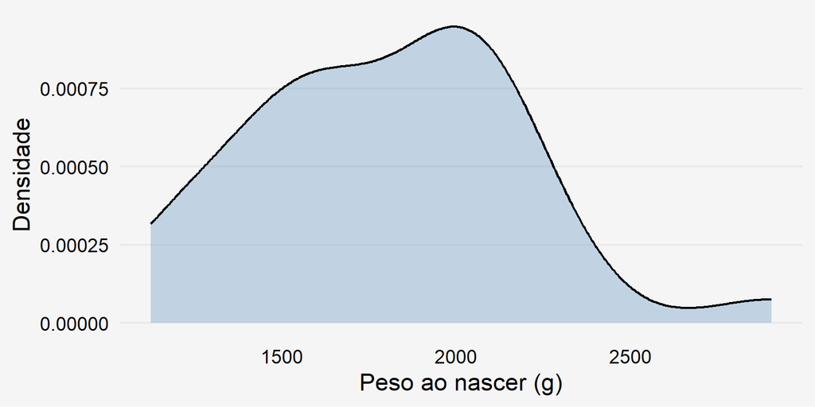

```r
ggplot(individuos, aes(x = peso_nascimento)) +
  geom_density(fill = "steelblue", alpha = 0.3) +
  labs(x = "Peso ao nascer (g)", y = "Densidade") + tema()
```

**Mostrar código R**

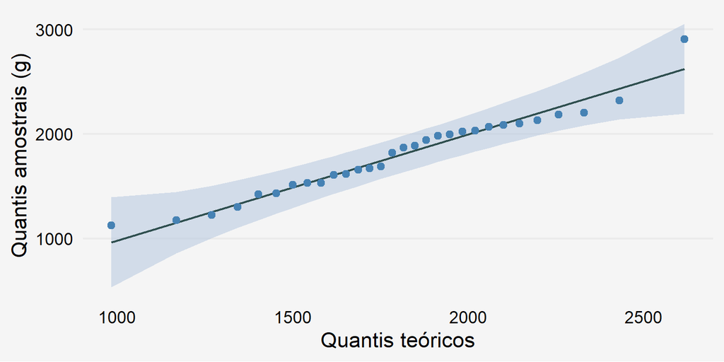

```r
library(qqplotr)
ggplot(individuos, aes(sample = peso_nascimento)) +
  stat_qq_band(fill = "lightsteelblue", alpha = 0.5) +
  stat_qq_line(color = "darkslategray") +
  stat_qq_point(color = "steelblue") +
  labs(x = "Quantis teóricos", y = "Quantis amostrais (g)") + tema()
```

**Mostrar código R**

```r
diagnostico <- shapiro.test(individuos$peso_nascimento)
diagnostico
```

```
    Shapiro-Wilk normality test

data:  individuos$peso_nascimento
W = 0.96263, p-value = 0.3609
```

O teste acima fornece p = **0,3609**. Ao nível de 5%, não há evidência suficiente para rejeitar a normalidade do peso ao nascer. A decisão deve ser lida junto ao gráfico e ao tamanho amostral.

## Resultados publicados completos

### Comparação pareada entre métodos

**Mostrar código R**

```r
tabela_resultados()
```

[output not shown]

Valores-p transcritos, não recalculados. Para o derramamento, o campo `p_limite = 0.001` no arquivo representa o **limite superior** da desigualdade publicada `p < 0,001`, não um p exato.

### Comparação AIG e PIG

**Mostrar código R**

```r
subgrupos |>
  left_join(select(metodos, id, variavel, unidade), by = "id") |>
  transmute(Método = metodo, Variável = paste0(variavel," (",unidade,")"),
    `AIG: média (DP)` = paste0(numero(aig_media,2)," (",numero(aig_dp,2),")"),
    `PIG: média (DP)` = paste0(numero(pig_media,2)," (",numero(pig_dp,2),")"),
    `Valor-p` = numero(p,3)) |>
  gt(groupname_col = "Método") |>
  tab_options(table.font.size = px(16))
```

| Variável | AIG: média (DP) | PIG: média (DP) | Valor-p |
| --- | --- | --- | --- |
| TSD |  |  |  |
| Volume oferecido (%) | 69,60 (22,00) | 92,80 (13,00) | 0,003 |
| Volume oferecido em 5 min (%) | 35,00 (10,50) | 41,50 (11,40) | 0,122 |
| Volume derramado (%) | 2,30 (4,10) | 2,40 (5,80) | 0,965 |
| Relação volume/tempo (mL/min) | 3,04 (0,97) | 3,42 (1,01) | 0,316 |
| Tempo (min) | 9,90 (3,14) | 11,38 (3,13) | 0,218 |
| Seringa |  |  |  |
| Volume oferecido (%) | 87,00 (14,40) | 91,50 (11,50) | 0,383 |
| Volume oferecido em 5 min (%) | 38,60 (8,60) | 40,30 (9,50) | 0,608 |
| Volume derramado (%) | 16,60 (7,60) | 17,90 (7,10) | 0,634 |
| Relação volume/tempo (mL/min) | 3,34 (0,68) | 3,27 (0,90) | 0,827 |
| Tempo (min) | 11,27 (2,91) | 11,56 (2,49) | 0,781 |

Tabela 2 do artigo. AIG n = 18; PIG n = 12. ANOVA conforme a legenda original. A tabela em slides simplifica a exibição para médias e p; aqui os desvios padrão também estão presentes.

### Sinais vitais

**Mostrar código R**

```r
sinais |>
  select(variavel, unidade, metodo, momento, media, ic_margem, dp) |>
  gt(groupname_col = "variavel") |>
  fmt_number(columns = c(media,ic_margem,dp), decimals = 2, dec_mark = ",") |>
  cols_label(ic_margem = "Margem de IC publicada", dp = "DP", media = "Média")
```

| unidade | metodo | momento | Média | Margem de IC publicada | DP |
| --- | --- | --- | --- | --- | --- |
| Saturação de oxigênio |  |  |  |  |  |
| % | TSD | Antes | 95,87 | 0,86 | 2,40 |
| % | TSD | Durante | 94,37 | 1,61 | 4,51 |
| % | TSD | Depois | 95,67 | 0,74 | 2,06 |
| % | Seringa | Antes | 93,23 | 2,04 | 5,71 |
| % | Seringa | Durante | 93,60 | 1,69 | 4,72 |
| % | Seringa | Depois | 95,90 | 0,76 | 2,12 |
| Frequência cardíaca |  |  |  |  |  |
| bpm | TSD | Antes | 134,20 | 3,65 | 10,21 |
| bpm | TSD | Durante | 149,17 | 4,61 | 12,90 |
| bpm | TSD | Depois | 145,50 | 2,59 | 7,25 |
| bpm | Seringa | Antes | 133,60 | 3,78 | 10,57 |
| bpm | Seringa | Durante | 148,07 | 2,66 | 7,43 |
| bpm | Seringa | Depois | 144,73 | 3,50 | 9,77 |

Transcrição das Figuras 4 e 5. As margens são as distâncias “±” publicadas e não IC da diferença entre métodos ou momentos. Não foram usadas para inferir significância pelo simples cruzamento de intervalos.

## Como seriam os testes em R?

Os blocos desta seção têm **`eval: false`**: ilustram a estrutura correta, mas não são executados, porque faltam os desfechos individuais. `dados_pareados` e `dados_longos` são nomes de bases que precisariam ser obtidas com os autores, e não arquivos presentes neste projeto.

### Teste t pareado e diagnóstico das diferenças

**Mostrar código R**

```r
dados_pareados <- dados_pareados |>
  mutate(diferenca = derramamento_seringa - derramamento_tsd)
shapiro.test(dados_pareados$diferenca)
t.test(dados_pareados$derramamento_seringa,
       dados_pareados$derramamento_tsd,
       paired = TRUE, alternative = "two.sided", conf.level = 0.95)
```

### ANOVA entre AIG e PIG

**Mostrar código R**

```r
by(dados_pareados$volume_tsd, dados_pareados$grupo, shapiro.test)
DescTools::LeveneTest(volume_tsd ~ grupo, data = dados_pareados)
modelo <- aov(volume_tsd ~ grupo, data = dados_pareados)
summary(modelo)
# Com apenas dois grupos, não há necessidade de pós-teste para localizar o par.
```

O artigo utiliza ANOVA na Tabela 2. A aplicação acima depende de independência entre bebês, distribuição dos erros e variâncias. Welch seria uma alternativa se as variâncias não fossem assumidas iguais, conforme o contexto.

### Três momentos do mesmo bebê

**Mostrar código R**

```r
# Exemplo didático balanceado, para UMA técnica, com dados completos.
dados_longos$id <- factor(dados_longos$id)
dados_longos$momento <- factor(dados_longos$momento,
                             levels = c("Antes", "Durante", "Depois"))
modelo_repetido <- aov(saturacao ~ momento + Error(id/momento),
                      data = dados_longos)
summary(modelo_repetido)
```

Esse é apenas um esqueleto de ANOVA de medidas repetidas. A inferência ainda exige avaliar suposições, incluindo esfericidade no caso univariado com três momentos e correções quando necessárias. O artigo não apresenta os detalhes para confirmar a implementação. `TukeyHSD()` sobre uma ANOVA de grupos independentes não corrige a dependência dessas medidas. As comparações posteriores devem ser compatíveis com o modelo de medidas repetidas. Não afirmamos que este foi o código ou o modelo empregado pelos autores.

## Sensibilidade à multiplicidade

Os autores apresentam cinco testes t na Tabela 3 e não descrevem ajuste conjunto para essa família. Se os cinco fossem tratados como uma família com Bonferroni, o limiar seria:

**Mostrar código R**

```r
0.05 / nrow(metodos)
```

```
[1] 0.01
```

Sob essa escolha didática, `p < 0,001` continuaria abaixo de 0,01, mas `p = 0,029` não. Isso não substitui a análise original nem pressupõe que Bonferroni fosse obrigatório. Não calculamos um p ajustado exato para o derramamento, porque só foi publicado um limite.

## Recursos das aulas utilizados

| Aula | Aplicação neste projeto |
| --- | --- |
| Quarto | YAML, Reveal.js, CSS, capítulos, colunas, caixas, abas, links, equações, chunks com nomes e opções, notas do apresentador |
| Tabelas | `read.xlsx()`, `select()`, `mutate()`, `tbl_summary()`, `modify_header()`, `bold_labels()`, `as_gt()`, `tab_options()` |
| Gráficos e diagnósticos | `ggplot()`, `geom_density()`, `stat_qq_band()`, `stat_qq_line()`, `stat_qq_point()`, `shapiro.test()` |
| Testes | Explicação de t pareado, ANOVA, Tukey e multiplicidade; códigos de testes não reproduzíveis marcados como não executáveis |
| Extensão solicitada | Dashboard Quarto, seleção de indicadores e gráficos interativos locais |

Não usamos qui-quadrado, Fisher ou V de Cramér para comparar estes desfechos quantitativos. Não usamos testes automáticos do `gtsummary` com resumos agregados para simular uma análise individual.

## Informações da execução

**Mostrar código R**